# Data Insights

### Created by Sundus Housah

The data provided in this project have been processed by applying three data wrangling steps summarized in Data gathering, data cleaning and data visualization. As a result of completing this process the following questions were purposed in order to get close insight to the data.  
**Questions for insights from the data**

- What is the most favorite dog breed?
- What is the most common name used for dogs?
- What dog stage have higher ratings compare to other stages?  
  By using the numpy and pandas functionalities I was able to answer the previous questions and figure that the **Labrador Retriever** the most favourate dog breed after grouping the data according to the dog bread and summing the favorite counts for all p1,p2 and p3  
  Also, I found out that **Cooper** is the most dog name given after excluding the 'Nan' values and the 'a' values, where **Bo** and **Charlie** come in second and third.  
  It seems like people are more drawn to doges in their **pupper** stage where the dog is still young, playful and fun. I came up with this conclusion according to the 137.9 rating calculated result for this dog age. This finding have been confirmed after generating a bar graph that shows the relation between the doge stage and the rating using matplotlib library.Where appose to **pupper** stage, **floffer** stage seams the least favorite one.

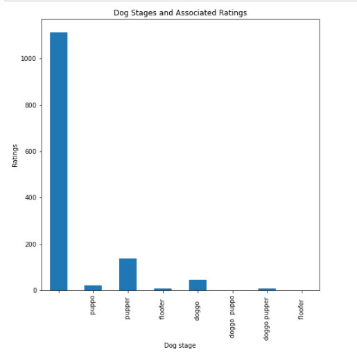